# MFML_HW_5

```python
from sklearn.linear_model import LinearRegression as LR
import seaborn as sns
import numpy as np
import pandas as pd
import matplotlib.pyplot as plt
import statsmodels.formula.api as smf
import sklearn.metrics as skm
from sklearn.metrics import f1_score
import statsmodels.graphics.regressionplots as regplts
from sklearn.decomposition import PCA
import numpy.linalg as la
import random
import numpy as np
import matplotlib.pyplot as plt
import scipy.io as sio
import sys
from sklearn.model_selection import train_test_split
from sklearn.decomposition import TruncatedSVD
%pip install matplotlib inline
from PIL import Image
```

```python
data = np.load ("/Users/deancasey/Downloads/blurring.npz")
X = data['X']
y = data['y']
```

```python
X.shape, y.shape
```

```
((529, 500), (529, 1))
```

```python
#w_LS = la.inv(X.T@X)@X.T@y
U,S,Vt = la.svd(X,full_matrices = False)
S_diag = np.diag(S)
w_LS = Vt.T@la.inv(S_diag.T@S_diag)@S_diag.T@U.T@y
```

```python
S_15 = S.copy()
S_15[15:] = 0
S_15.shape
```

```
(500,)
```

```python
S_diag.shape
```

```
(500, 500)
```

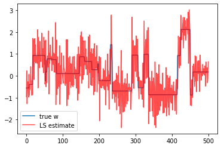

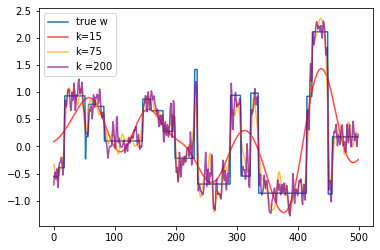

```python
U,S,Vt = la.svd (X,full_matrices = False)
S_diag = np.diag(S)

# Estimate w using X and y with regular least squares

#w_LS = Vt.T@la.inv(S_diag.T@S_diag)@S_diag.T@U.T@y
w_LS = la.inv(X.T@X)@X.T@y

# Estimate w using X and y with truncated SVD
S_15 = S.copy()
S_15[15:] = 0
S_15_diag = np.diag(S_15)

S_75 = S.copy()
S_75[75:] = 0
S_75_diag = np.diag(S_75)

S_200 = S.copy()
S_200[200:] = 0
S_200_diag = np.diag(S_200)

w_15 = Vt.T@la.pinv(S_15_diag.T@S_15_diag)@S_15_diag.T@U.T@y
w_75 = Vt.T@la.pinv(S_75_diag.T@S_75_diag)@S_75_diag.T@U.T@y
w_200 = Vt.T@la.pinv(S_200_diag.T@S_200_diag)@S_200_diag.T@U.T@y

# Compare estimate to true value for LS

plt.plot(data['w'],label ='true w')
plt.plot(w_LS,alpha =0.7,c ='red',label ='LS estimate')
plt.legend ()
plt.show()
plt.plot(data['w'],label ='true w')
plt.plot(w_15,alpha=0.7,c ='red',label ='k=15')
plt.plot(w_75,alpha=0.7,c ='orange',label ='k=75')
plt.plot(w_200,alpha=0.7,c ='purple',label ='k =200')
plt.legend()
plt.show()
```

```python
A = np.array([
    [0, 0, 0, 1],
    [1, 0, 0, 0],
    [0, 0.5, 0, 0],
    [0, 0.5, 1, 0]
])
```

```python
pi = np.matrix([.25,.25,.25,.25]).T
```

```python
num_iterations = 1000
for _ in range(num_iterations):
    numerator = A@pi
    denumerator = numerator.sum(axis=0)
    pi = numerator/denumerator

print('Final pi:', pi)
```

```
Final pi: [[0.28571429]
 [0.28571429]
 [0.14285714]
 [0.28571429]]
```

```python
test = np.array([1,1,0.5,1])
test = test/test.sum(axis=0)
test
```

```
array([0.28571429, 0.28571429, 0.14285714, 0.28571429])
```

```python
alpha = 0.8
```

```python
ones = np.ones((4,4))
ones
```

```
array([[1., 1., 1., 1.],
       [1., 1., 1., 1.],
       [1., 1., 1., 1.],
       [1., 1., 1., 1.]])
```

```python
G = alpha*A +(1-alpha)*(1/4)*ones@ones.T
G = G/G.sum(axis=0)
G
```

```
array([[0.125, 0.125, 0.125, 0.625],
       [0.625, 0.125, 0.125, 0.125],
       [0.125, 0.375, 0.125, 0.125],
       [0.125, 0.375, 0.625, 0.125]])
```

```python
pi2 = np.matrix([.25,.25,.25,.25]).T
num_iterations = 1000
for _ in range(num_iterations):
    numerator = G@pi2
    denumerator = numerator.sum(axis=0)
    pi2 = numerator/denumerator

print('Final pi:', pi2)
```

```
Final pi: [[0.26724138]
 [0.25862069]
 [0.18965517]
 [0.28448276]]
```

```python
pi2.sum(axis=0)
```

```
matrix([[1.]])
```

```python
img.shape
```

```
(375, 500, 3)
```

[figure not shown]

```
(375, 1500)
```

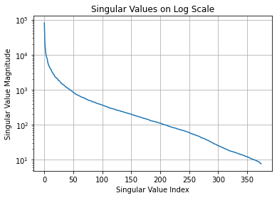

```python
img = Image.open("/Users/deancasey/Downloads/disaster-girl.jpg", mode ="r")
img = np.array(img).astype(np.int32)
plt.imshow(img)
plt.title('Original Picture')
plt.show()

# note that images usually have 3 channels
# so , you can reshape it

img_stack = img.reshape((img.shape[0],-1))
print(img_stack.shape)
U,S,Vt = la.svd(img_stack,full_matrices=False)
plt.figure()
plt.semilogy(S)
plt.title('Singular Values on Log Scale')
plt.xlabel('Singular Value Index')
plt.ylabel('Singular Value Magnitude')
plt.grid(True)
plt.show()
```

```python
image = img
```

```python
R.shape, G.shape, B.shape
```

```
((375, 500), (4, 4), (375, 500))
```

```python
X_Rk.shape, X_Gk.shape, X_Bk.shape
```

```
((375, 500), (375, 500), (375, 500))
```

```python
reconst_matrix.shape
```

```
(375, 500, 3)
```

[figure not shown]

```python
plt.imshow(img)
```

```python
img.shape
```

```
(375, 500, 3)
```

```python
U, S, Vt = la.svd(img, full_matrices=False)
U.shape, S.shape, Vt.shape
```

```
((375, 500, 3), (375, 3), (375, 3, 3))
```

```python
S_diag.shape
```

```
(500, 500)
```

```python
reconst_matrix[:,:,0].shape
```

```
(375, 500)
```

```python
S_kR_diag.shape
```

```
(20, 20)
```

```python
U_R.shape
```

```
(375, 20)
```

```
Clipping input data to the valid range for imshow with RGB data ([0..1] for floats or [0..255] for integers).
```

[figure not shown]

```python
n,p,z = image.shape
k=20
R = image[:,:,0]
G = image[:,:,1]
B = image[:,:,2]

U_R, S_R, Vt_R = la.svd(R, full_matrices=False)
U_G, S_G, Vt_G = la.svd(G, full_matrices=False)
U_B, S_B, Vt_B = la.svd(B, full_matrices=False)

S_kR = S_R.copy()
S_kR = S_kR[:k]
S_kR_diag = np.diag(S_kR)
U_R = U_R[:,:k]
Vt_R = Vt_R[:k,:]

S_kG = S_G.copy()
S_kG = S_kG[:k]
S_kG_diag = np.diag(S_kG)
U_G = U_G[:,:k]
Vt_G = Vt_G[:k,:]

S_kB = S_B.copy()
S_kB = S_kB[:k]
S_kB_diag = np.diag(S_kB)
U_B = U_B[:,:k]
Vt_B = Vt_B[:k,:]


X_Rk = U_R@S_kR_diag@Vt_R
X_Gk = U_G@S_kG_diag@Vt_G
X_Bk = U_B@S_kB_diag@Vt_B

reconst_matrix=np.zeros((n,p,z))
reconst_matrix[:,:,0] = X_Rk
reconst_matrix[:,:,1] = X_Gk
reconst_matrix[:,:,2] = X_Bk

reconst_matrix = np.array(reconst_matrix).astype(np.int32)
plt.imshow(reconst_matrix)
```

```python
def compress(image,k):
    n,p,z = image.shape
    R = image[:,:,0]
    G = image[:,:,1]
    B = image[:,:,2]

    U_R, S_R, Vt_R = la.svd(R, full_matrices=False)
    U_G, S_G, Vt_G = la.svd(G, full_matrices=False)
    U_B, S_B, Vt_B = la.svd(B, full_matrices=False)

    S_kR = S_R.copy()
    S_kR = S_kR[:k]
    S_kR_diag = np.diag(S_kR)
    U_R = U_R[:,:k]
    Vt_R = Vt_R[:k,:]

    S_kG = S_G.copy()
    S_kG = S_kG[:k]
    S_kG_diag = np.diag(S_kG)
    U_G = U_G[:,:k]
    Vt_G = Vt_G[:k,:]

    S_kB = S_B.copy()
    S_kB = S_kB[:k]
    S_kB_diag = np.diag(S_kB)
    U_B = U_B[:,:k]
    Vt_B = Vt_B[:k,:]

    X_Rk = U_R@S_kR_diag@Vt_R
    X_Gk = U_G@S_kG_diag@Vt_G
    X_Bk = U_B@S_kB_diag@Vt_B

    reconst_matrix=np.zeros((n,p,z))
    reconst_matrix[:,:,0] = X_Rk
    reconst_matrix[:,:,1] = X_Gk
    reconst_matrix[:,:,2] = X_Bk

    reconst_matrix = np.array(reconst_matrix).astype(np.int32)

    return reconst_matrix
```

```python
compress(img,20).shape
```

```
(375, 500, 3)
```

```
Clipping input data to the valid range for imshow with RGB data ([0..1] for floats or [0..255] for integers).
Clipping input data to the valid range for imshow with RGB data ([0..1] for floats or [0..255] for integers).
Clipping input data to the valid range for imshow with RGB data ([0..1] for floats or [0..255] for integers).
```

[figure not shown]

```python
fig, axes = plt.subplots(1, 4, figsize=(15, 5))
axes[0].imshow(image)
axes[0].set_title('Original Image')
axes[1].imshow(compress(img,5))
axes[1].set_title('K = 5')
axes[2].imshow(compress(img,20))
axes[2].set_title('K = 20')
axes[3].imshow(compress(img,50))
axes[3].set_title('K = 50')
```

```python
destiny = Image.open("/Users/deancasey/Desktop/Random Pictures/Destiny Wallpaper.jpeg",mode='r')
destiny = np.array(destiny).astype(np.int32)
destiny.shape
```

```
(4800, 7680, 3)
```

```python
compress(destiny,500)
```

[output not shown]

```
Clipping input data to the valid range for imshow with RGB data ([0..1] for floats or [0..255] for integers).
Clipping input data to the valid range for imshow with RGB data ([0..1] for floats or [0..255] for integers).
Clipping input data to the valid range for imshow with RGB data ([0..1] for floats or [0..255] for integers).
```

[figure not shown]

```python
destiny = Image.open("/Users/deancasey/Desktop/Random Pictures/Destiny Wallpaper.jpeg",mode='r')
destiny = np.array(destiny).astype(np.int32)

fig, axes = plt.subplots(1, 4, figsize=(15, 5))
axes[0].imshow(destiny)
axes[0].set_title('Original Image')
axes[1].imshow(compress(destiny,5))
axes[1].set_title('K = 5')
axes[2].imshow(compress(destiny,20))
axes[2].set_title('K = 20')
axes[3].imshow(compress(destiny,50))
axes[3].set_title('K = 50')
```

```python
relative = []
for i in range(500):
    reconst_matrix = compress(image,i)
    error = la.norm(img-reconst_matrix)/la.norm(img)
    relative.append(error)
```

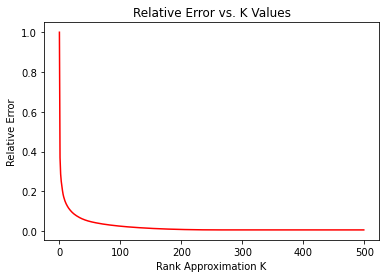

```python
k_values = np.arange(500)
plt.plot(k_values,relative,color='r')
plt.title('Relative Error vs. K Values')
plt.xlabel('Rank Approximation K')
plt.ylabel('Relative Error')
plt.show()
```

It seems that the relative error exponentially decays with higher values of k for rank approximation. It's hard to tell visually from the graph, but there seems to be an inflection point somewhere around 20-40 for the rank approximation where the relative error seems to plateau out, indicating that most of the necessary information is within this range of singular values.

```python
def compress_c(image,k):
    n,p,z = image.shape
    R = image[:,:,0]
    G = image[:,:,1]
    B = image[:,:,2]

    U_R, S_R, Vt_R = la.svd(R, full_matrices=False)
    U_G, S_G, Vt_G = la.svd(G, full_matrices=False)
    U_B, S_B, Vt_B = la.svd(B, full_matrices=False)

    S_kR = S_R.copy()
    S_kR = S_kR[:k]
    S_kR_diag = np.diag(S_kR)
    U_R = U_R[:,:k]
    Vt_R = Vt_R[:k,:]

    S_kG = S_G.copy()
    S_kG = S_kG[:k]
    S_kG_diag = np.diag(S_kG)
    U_G = U_G[:,:k]
    Vt_G = Vt_G[:k,:]

    S_kB = S_B.copy()
    S_kB = S_kB[:k]
    S_kB_diag = np.diag(S_kB)
    U_B = U_B[:,:k]
    Vt_B = Vt_B[:k,:]

    X_Rk = U_R@S_kR_diag@Vt_R
    X_Gk = U_G@S_kG_diag@Vt_G
    X_Bk = U_B@S_kB_diag@Vt_B

    reconst_matrix=np.zeros((n,p,z))
    reconst_matrix[:,:,0] = X_Rk
    reconst_matrix[:,:,1] = X_Gk
    reconst_matrix[:,:,2] = X_Bk

    reconst_matrix = np.array(reconst_matrix).astype(np.int32)

    U_c, S_c, Vt_c = la.svd(reconst_matrix, full_matrices=False)

    return U_R.size, Vt_R.size
```

```python
compress_c(image,5)
```

```
(1875, 2500)
```

```python
375*500*3
```

```
562500
```

```python
compressionU = []
compressionV = []
for i in range(500):
    sizeU = compress_c(image,i)[0]
    memoryU = (sizeU+i)/(image.size)
    compressionU.append(memoryU)
    sizeV = compress_c(image,i)[1]
    memoryV = (sizeV+i)/(image.size)
    compressionV.append(memoryV)
```

```python
U_new = compress_c(image,50)[0]
#image.size
memoryU = (U_new+i)/(image.size)
memoryU
```

```
0.03422044444444444
```

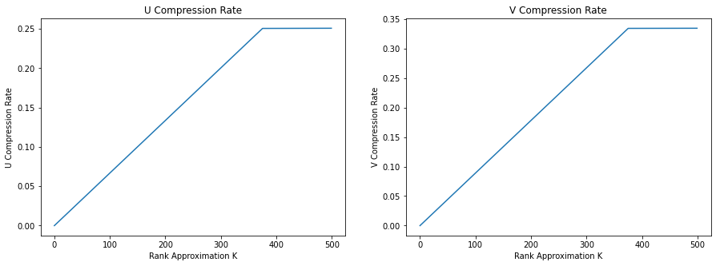

```python
k_values = np.arange(500)

fig, axes = plt.subplots(1, 2, figsize=(15, 5))
axes[0].plot(k_values,compressionU)
axes[0].set_title('U Compression Rate')
axes[0].set_ylabel('U Compression Rate')
axes[0].set_xlabel('Rank Approximation K')

axes[1].plot(k_values,compressionV)
axes[1].set_title('V Compression Rate')
axes[1].set_ylabel('V Compression Rate')
axes[1].set_xlabel('Rank Approximation K')

plt.show()
```

Both graphs show a linear trend, where the compression rate linearly depends on the k value, up until around k=375. This makes sense, because as the value of k increases by 1, you are increasing the numerator in the comrpession rate equation ever so slightly with an increase of 1 more singular value and one more column/row of U or V.

After analyzing these 2 graphs and the relative error graph, the approximation rank I would choose to compress this image would probably be somewhere around 20-30. These values of k seems to gather the most amount of information while keeping the compression rate relatively low.